# BT1101-Tutorial 4 (Deadline: 4 Mar 9am)

```r
# install required packages if you have not (suggested packages: dplyr, tidyr, rpivotTable, knitr, psych)
# install.packages("dplyr") #only need to run this code once to install the package
# load required packages
# library("xxxx")
library("dplyr") #need to call the library before you use the package
library("tidyr")
library("rpivotTable")
library("knitr")
library("psych")
library("RColorBrewer")
library("readxl")
```

### Tutorial 4 Part 2: CardioGood Fitness (To be Submitted; 25 marks)

Context: Your market research team at AdRight is assigned the task to identify the profile of the typical customer for each treadmill product offered by CardioGood Fitness. Your team decides to investigate whether there are differences across the product lines with respect to customer characteristics. The team decides to collect data on individuals who purchased a treadmill at a CardioGoodFitness retail store during the prior three months.

The data are stored in the `CardioGoodFitness.csv` file. The team identifies the following customer variables to study:

- `Product`: product purchased (TM195, TM498, or TM798)
- `Age`: in years
- `Gender`: Female or Male
- `Education`: number of years of education
- `MaritalStatus`: Single or Partnered
- `Usage`: average number of times the customer plans to use the treadmill each week
- `Fitness`: self-rated fitness on an 1-to-5 scale, where 1 is poor shape and 5 is excellent shape.
- `Income`: annual household income ($)
- `Miles`: average number of miles the customer expects to walk/run each week

You are tasked by your team to help in the tasks below toward creating a better understanding of the customer profile of the CardioGood Fitness treadmill product line.

```r
getwd()
```

```
## [1] "C:/Users/zandr/OneDrive/Desktop/R"
```

```r
setwd("C:/Users/zandr/OneDrive/Desktop/R")
d1 <- read.csv("CardioGoodFitness.csv")
head(d1)
```

```
##   Product Age Gender Education MaritalStatus Usage Fitness Income Miles
## 1   TM195  18   Male        14        Single     3       4  29562   112
## 2   TM195  19   Male        15        Single     2       3  31836    75
## 3   TM195  19 Female        14     Partnered     4       3  30699    66
## 4   TM195  19   Male        12        Single     3       3  32973    85
## 5   TM195  20   Male        13     Partnered     4       2  35247    47
## 6   TM195  20 Female        14     Partnered     3       3  32973    66
```

#### Q2.(a) Customer Profile by Product Dashboard (I).

This dashboard should enable the team to better understand the demographics of the customers for different types of treadmill products.

- 1. Create a table and pie chart to compare the frequency distributions for different product types.
- 2. Create a table and chart to compare the frequency distribution of different product types by `Gender` and another table and chart by `Marital Status`.
- 3. Type your observations from the charts in the space below. Do add the appropriate titles, labels, legend and use different shades of one color as the color palette for each chart. [You are not required to perform outlier analyses for this question part]

[8 marks]

**BEGIN: YOUR ANSWER**

```r
##Type your codes here
# i
ProductFreq <- d1 %>% count(Product)
kable(ProductFreq, caption = "Product type Frequency")
```

Product type Frequency

| Product | n |
| --- | --- |
| TM195 | 80 |
| TM498 | 60 |
| TM798 | 40 |

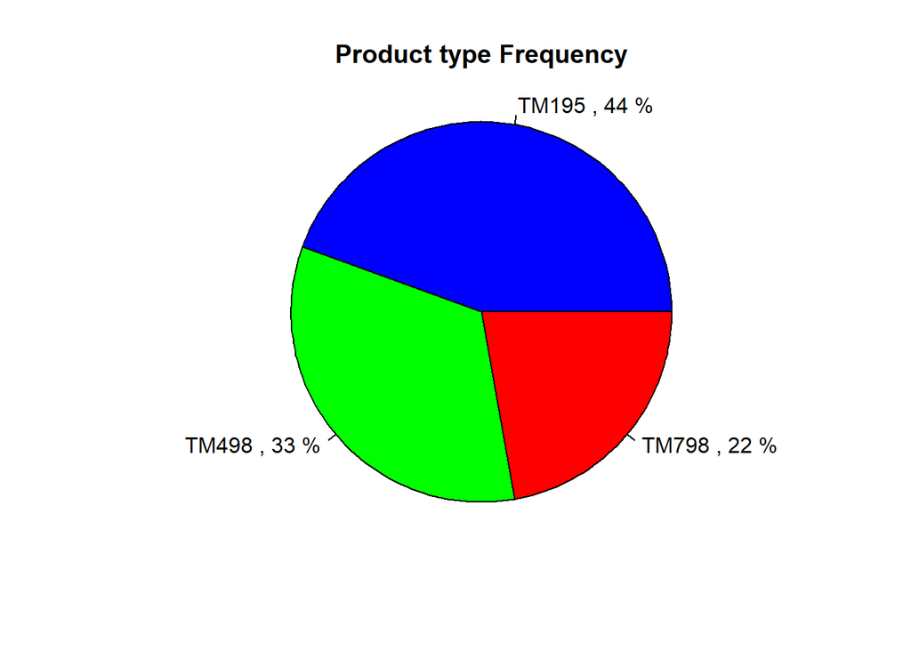

```r
slice.product <- ProductFreq$n
product.piepercent <- 100 * round(ProductFreq$n / sum(ProductFreq$n), 2)
label <- ProductFreq$Product
label <- paste(label, ",", sep = " ")
label <- paste(label, product.piepercent)
label <- paste(label, "%")

pie(slice.product, labels = label,
    col = c("blue", "green", "red", "cyan", "orange", "yellow"),
    radius = 1,
    main = "Product type Frequency")
```

```r
# ii
# gender
d1.1 <- d1 %>%
  group_by(Gender, Product) %>%
  tally()
d1.1spread <- d1.1 %>% spread(key = "Product", value = n)
kable(d1.1spread, caption = "Contingency table displaying frequency distribution of product types by gender")
```

Contingency table displaying frequency distribution of product types by gender

| Gender | TM195 | TM498 | TM798 |
| --- | --- | --- | --- |
| Female | 40 | 29 | 7 |
| Male | 40 | 31 | 33 |

```r
# marital status
d1.2 <- d1 %>%
  group_by(MaritalStatus, Product) %>%
  tally()
d1.2spread <- d1.2 %>% spread(key = "Product", value = n)
kable(d1.2spread, caption = "Contingency table displaying frequency distribution of product types by martial status")
```

Contingency table displaying frequency distribution of product types by martial status

| MaritalStatus | TM195 | TM498 | TM798 |
| --- | --- | --- | --- |
| Partnered | 48 | 36 | 23 |
| Single | 32 | 24 | 17 |

```r
# iii
# observations in the space below
```

44% TM195, 22% TM789, 33% TM498

number of TM195 bought by: 40 males, 40 females number of TM498 bought by: 31 males, 29 females number of TM798 bought by: 33 males, 7 females

number of TM195 bought by: 48 partnered, 32 single number of TM498 bought by: 36 partnered, 24 single number of TM798 bought by: 23 partnered, 17 single

**END: YOUR ANSWER**

#### Q2.(b) Customer Profile by Product Dashboard (II).

Next create a second dashboard with the following requirements:

- 1. To be able to view the summary statistics (mean, sd, min, max) for the `Age`, `Education`, `Usage`, `Fitness`, `Income`, and `Miles` of the customers in one table.
- 2. To be able to compare the means for `Fitness` and `Usage` across the 3 product types in a table and chart. How would you describe the customer profile for the 3 types of products in terms of fitness and education levels?
- 3. To be able to compare the means for `Usage` for the 3 product types by Gender in a table and chart. Again provide your interpretation from the chart.

Do add the appropriate titles and labels for each chart. [You are not required to perform outlier analyses for this question part]

[10 marks]

**BEGIN: YOUR ANSWER**

```r
##Type your codes here
# i
d1.a <- d1 %>% select(Age, Education, Usage, Fitness, Income, Miles)
describe(d1.a) %>%
  select(mean, sd, min, max)
```

```
##               mean       sd   min    max
## Age          28.79     6.94    18     50
## Education    15.57     1.62    12     21
## Usage         3.46     1.08     2      7
## Fitness       3.31     0.96     1      5
## Income    53719.58 16506.68 29562 104581
## Miles       103.19    51.86    21    360
```

```r
# ii
#table
d1.c <- d1 %>% group_by(Product) %>% summarise(IncomeMean = mean(Income), UsageMean = mean(Usage))
kable(d1.c, caption = "Means of income and usage across all 3 product types")
```

Means of income and usage across all 3 product types

| Product | IncomeMean | UsageMean |
| --- | --- | --- |
| TM195 | 46418.03 | 3.087500 |
| TM498 | 48973.65 | 3.066667 |
| TM798 | 75441.57 | 4.775000 |

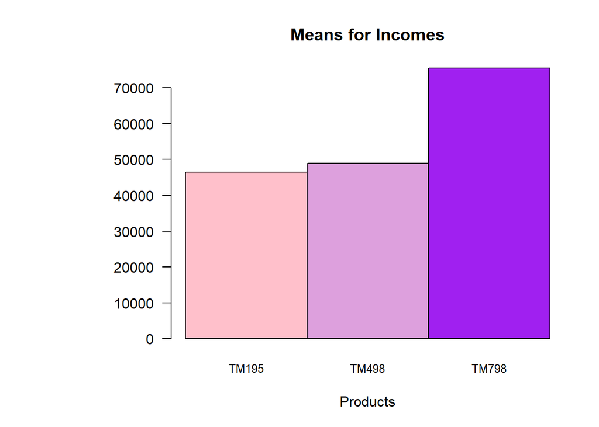

```r
# chart
# for income
par(mar = c(5, 10, 4, 2))
bar.d1c <- as.matrix(d1.c[, c(2)])
colours <- c("pink", "plum", "purple")
barplot(bar.d1c, beside = TRUE, col = colours, main = "Means for Incomes", cex.names = 0.8, las = 1, xlab = "Products", names.arg = c("TM195", "TM498", "TM798"))
```

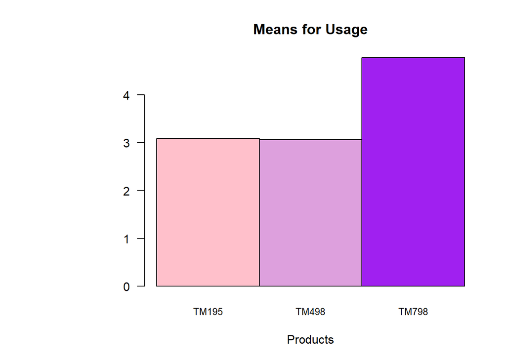

```r
# for usage
bar.d1c <- as.matrix(d1.c[, c(3)])
colours <- c("pink", "plum", "purple")
barplot(bar.d1c, beside = TRUE, col = colours, main = "Means for Usage", cex.names = 0.8, las = 1, xlab = "Products", names.arg = c("TM195", "TM498", "TM798"))
```

```r
# iii
# To be able to compare the means for `Usage` for the 3 product types by Gender in a table and chart
# table
selected <- d1 %>% select(Gender, Usage, Product)
selected3 <- selected %>% group_by(Gender, Product) %>% summarise(mean = mean(Usage))
kable(selected3)
```

| Gender | Product | mean |
| --- | --- | --- |
| Female | TM195 | 2.900000 |
| Female | TM498 | 3.137931 |
| Female | TM798 | 5.000000 |
| Male | TM195 | 3.275000 |
| Male | TM498 | 3.000000 |
| Male | TM798 | 4.727273 |

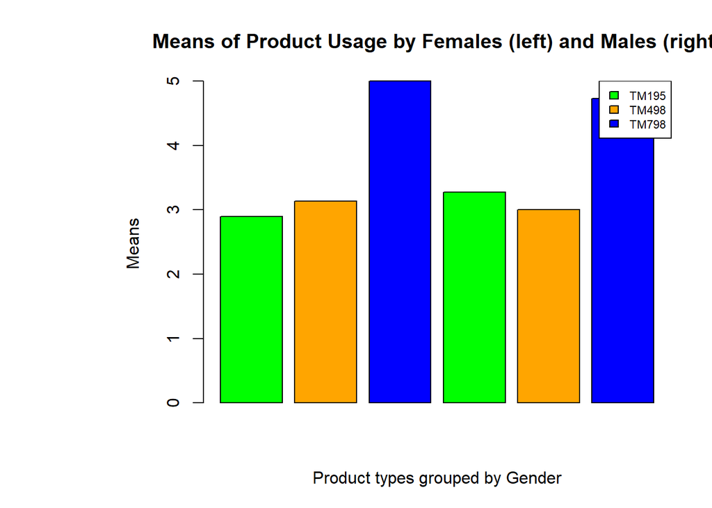

```r
# chart
value <- as.matrix(selected3)
colours <- c("green", "orange", "blue")
barplot(selected3$mean, main = "Means of Product Usage by Females (left) and Males (right)", col = colours, beside = TRUE, ylab = "Means", xlab = "Product types grouped by Gender")
legend("topright", c("TM195", "TM498", "TM798"), cex = 0.7, fill = colours)
```

Customers who buy the TM798 are the wealthiest group, followed by the TM498, then TM195. Customers tend to use the TM798 most, followed by the TM195, then the TM498.

The trend in usage for females – in increasing order of usage: TM195, TM498, TM798. For males – in increasing order of usage: TM498, TM196, TM798

**END: YOUR ANSWER**

#### Q2.(c) Inspect Customer Income Data

- 1. Conduct an outlier analyses on the `Income` variable. Describe your conclusion from this analyses.
- 2. Provide a chart and the appropriate statistic to analyse the linear association between `Income` and `Miles`. Type your interpretation of the results below.

[5 marks]

**BEGIN: YOUR ANSWER**

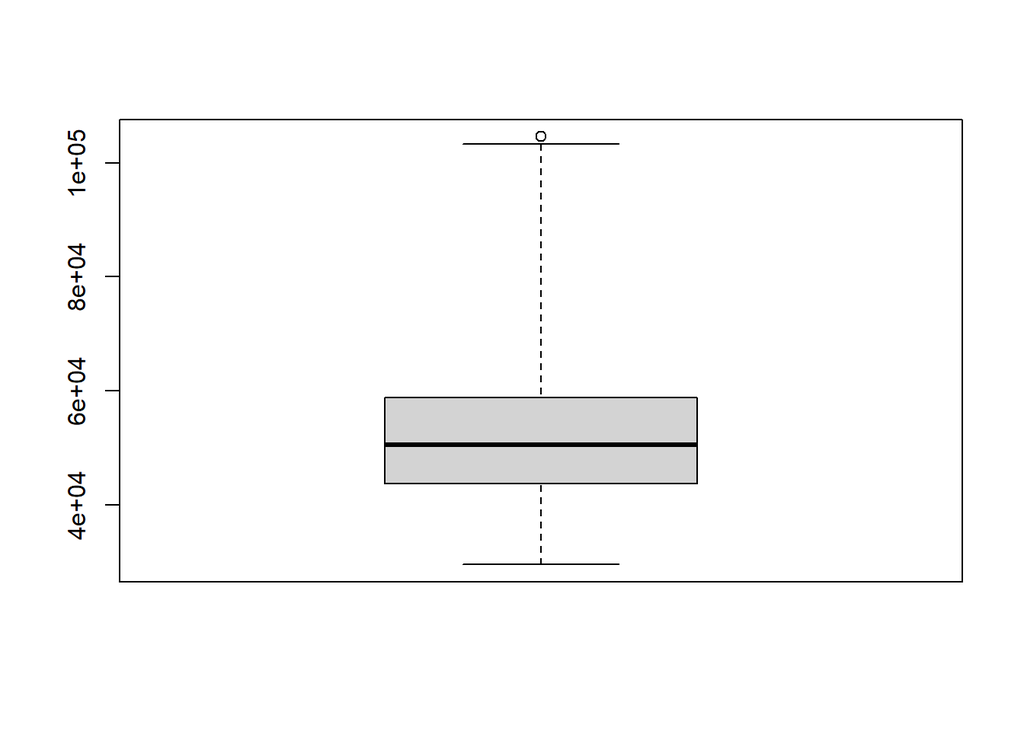

```r
##Type your codes here
# i
boxplot(d1$Income, range = 3)
```

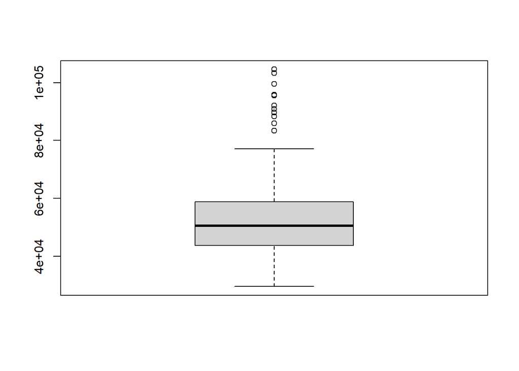

```r
boxplot(d1$Income, range = 1.5)
```

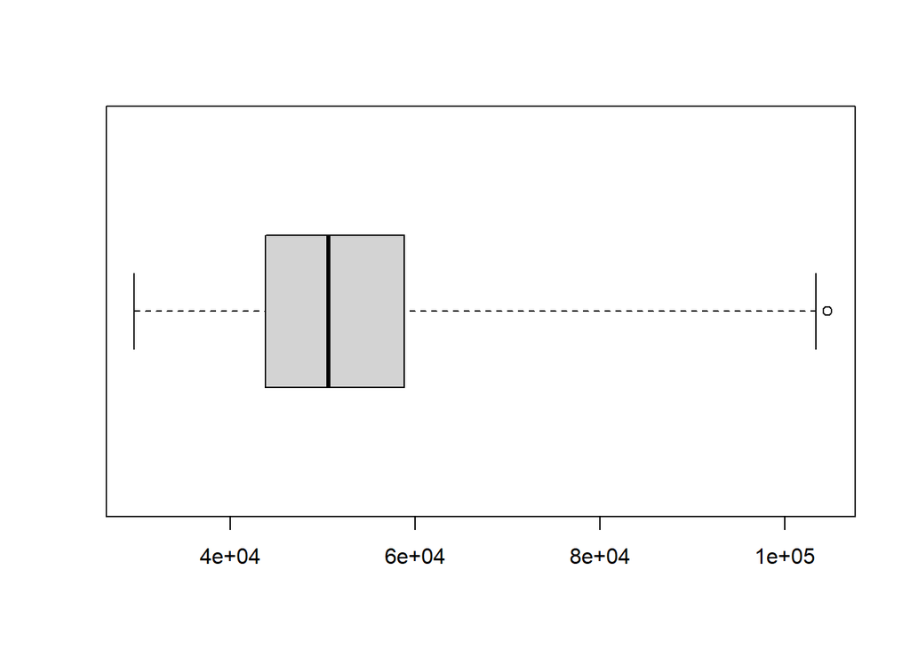

```r
incom1 <- boxplot(d1$Income, horizontal = TRUE, range = 3)
```

```r
incom1$out
```

```
## [1] 104581 104581
```

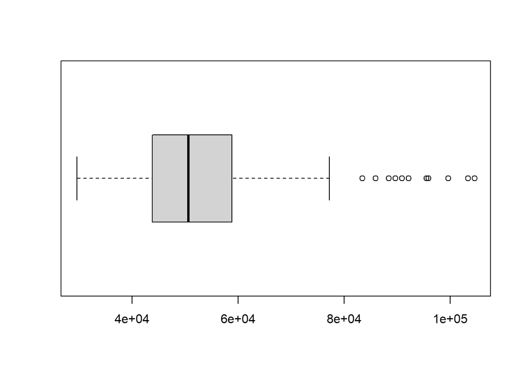

```r
incom2 <- boxplot(d1$Income, horizontal = TRUE, range = 1.5)
```

```r
incom2$out
```

```
##  [1]  83416  88396  90886  92131  88396  85906  90886 103336  99601  89641
## [11]  95866  92131  92131 104581  83416  89641  90886 104581  95508
```

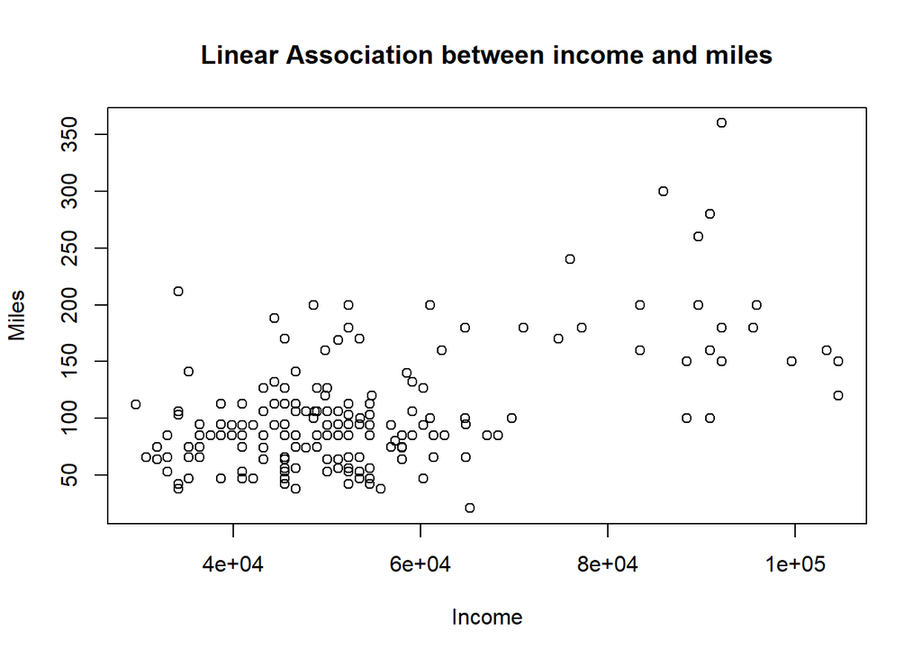

```r
# ii
plot(d1$Income, d1$Miles, main = "Linear Association between income and miles", xlab = "Income", ylab = "Miles", axes = TRUE)
```

```r
cov(d1$Income, d1$Miles)
```

```
## [1] 465265.4
```

**END: YOUR ANSWER**

#### Q2.(d) Compute Probabilities

Provide the following probability computation on the dashboard:

- 1. probability of a customer who has purchased a TM195, has an annual household income more than $62,000
- 2. probability of a male customer purchasing a TM798 (and not the other treadmills)

Use the dataset to compute these probabilities

[2 marks]

**BEGIN: YOUR ANSWER**

```r
##Type your codes here
#i
boughtTM195 <- d1 %>% filter(Product == "TM195")
totalBought <- nrow(boughtTM195)
incomeOver62000 <- boughtTM195 %>% filter(Income > 62000)
totalOver62000 <- nrow(incomeOver62000)
p1 <- totalOver62000 / totalBought
p1
```

```
## [1] 0.0375
```

```r
#ii
boughtTM986 <- d1 %>% filter(Product == "TM798")
totalTM798 <- nrow(boughtTM986)
totalBuys <- nrow(d1)
p2 <- totalTM798 / totalBuys
p2
```

```
## [1] 0.2222222
```

**END: YOUR ANSWER**